# PA1_template

rahul bhatia

December 14, 2014

Loading Data :

```r
  library(lattice)
  actdata<-read.csv("activity.csv",na.strings="NA",colClasses=c("numeric","character","numeric"))
  actdata$date <- as.Date(actdata$date , "%Y-%m-%d")
```

Histogram of the total number of steps taken each day:

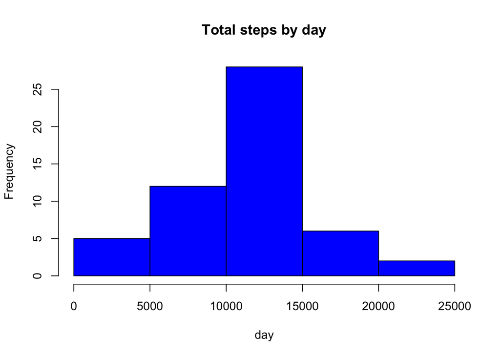

```r
  Totalsteps <- aggregate(steps ~ date, data = actdata, sum, na.rm = TRUE)
  hist(Totalsteps$steps, main = "Total steps by day", xlab = "day", col = "blue")
```

The mean and median total number of steps taken per day:

```r
  mean(Totalsteps$steps)
```

```
## [1] 10766.19
```

```r
  median(Totalsteps$steps)
```

```
## [1] 10765
```

time series plot (i.e. type = “l”) of the 5-minute interval (x-axis) and the average number of steps taken, averaged across all days (y-axis):

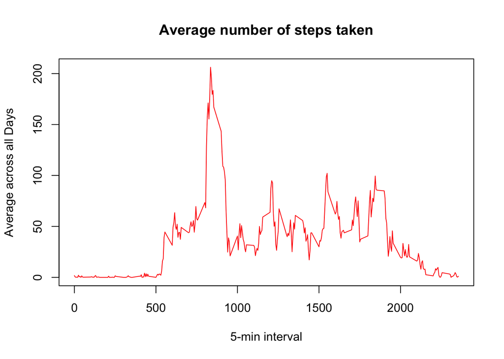

```r
  tsdata <- tapply(actdata$steps, actdata$interval, mean, na.rm = TRUE)
  plot(row.names(tsdata), tsdata, type = "l", xlab = "5-min interval",
       ylab = "Average across all Days", main = "Average number of steps taken",
       col = "red")
```

Which 5-minute interval, on average across all the days in the dataset, contains the maximum number of steps:

```r
   max_intervl <- which.max(tsdata)
   names(max_intervl)
```

```
## [1] "835"
```

the total number of missing values in the dataset (i.e. the total number of rows with NAs):

```r
   act_NA <- sum(is.na(actdata))
   act_NA
```

```
## [1] 2304
```

The strategy does not need to be sophisticated:the mean used to fill missing:

```r
  StepsMean <- aggregate(steps ~ interval, data = actdata, FUN = mean)
  fillMissing <- numeric()
  for (i in 1:nrow(actdata)) {
    obs <- actdata[i, ]
    if (is.na(obs$steps)) {
      steps <- subset(StepsMean, interval == obs$interval)$steps
    } else {
      steps <- obs$steps
    }
    fillMissing <- c(fillMissing, steps)
  }

  new_actdata <- actdata
  new_actdata$steps <- fillMissing
```

histogram of the total number of steps taken each day :

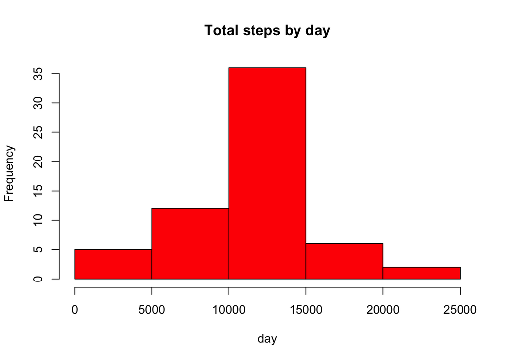

```r
  TotalSteps2 <- aggregate(steps ~ date, data = new_actdata, sum, na.rm = TRUE)
  hist(TotalSteps2$steps, main = "Total steps by day", xlab = "day", col = "red")
```

the mean and median total number of steps taken per day:

```r
  mean(TotalSteps2$steps)
```

```
## [1] 10766.19
```

```r
  median(TotalSteps2$steps)
```

```
## [1] 10766.19
```

yeah the median differs:

new factor variable in the dataset with two levels – “weekday” and “weekend” indicating whether a given date is a weekday or weekend day:

```r
  day <- weekdays(actdata$date)
  daylevel <- vector()
  for (i in 1:nrow(actdata)) {
    if (day[i] == "Saturday") {
      daylevel[i] <- "Weekend"
    } else if (day[i] == "Sunday") {
      daylevel[i] <- "Weekend"
    } else {
      daylevel[i] <- "Weekday"
    }
  }
  actdata$daylevel <- daylevel
  actdata$daylevel <- factor(actdata$daylevel)

  stepsPerDay <- aggregate(steps ~ interval + daylevel, data = actdata, mean)
  names(stepsPerDay) <- c("interval", "daylevel", "steps")
```

panel plot containing a time series plot (i.e. type = “l”) of the 5-minute interval (x-axis) and the average number of steps taken, averaged across all weekday days or weekend days (y-axis):

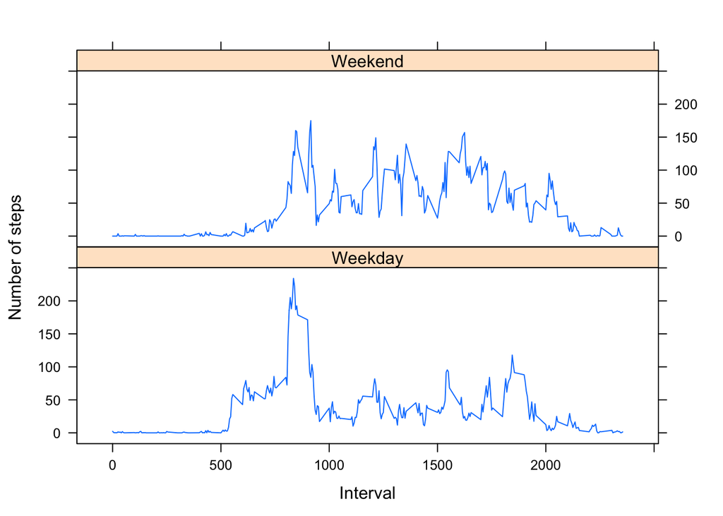

```r
   xyplot(steps ~ interval | daylevel, stepsPerDay, type = "l", layout = c(1, 2),
         xlab = "Interval", ylab = "Number of steps")
```